# HEAL_CSCS_2025_patterns_of_social_connection

Jorge Andres Delgado-Ron

2025-04-15

Step 0. Loading packages, opening dataset, and metadata

```r
# This pakcage runs the script below for all future packages using p_load()
if (!("pacman" %in% installed.packages()[, "Package"])) {
    # Install the 'pacman' package if it's not installed
    install.packages("pacman")
}

library("pacman")
p_load(here)
p_load(dplyr)
p_load(DataExplorer)
p_load(tableone)

load(here("cscs","public_data","CSCS2025_full_cleaned_deidentified_data_and_metadata.RData"))
```

Custom functions

```r
# Input variable as text
# Returns the unique label(s) and which data frame(s) contain it.

which_dataset <- function(variable){
levels(data$DATASET) <- c("baseline", "baseline", "cohort22", "cross22", "cohort23", "cross23", "cohort24", "cross24")
x <- data %>% select(DATASET, !!sym(variable)) %>% group_by(DATASET) %>% summarise(result = !all(is.na(!!sym(variable)))) %>% select(DATASET, result)  %>% arrange(as.character(DATASET))
y <- unique(labels$text[labels$new_var==variable])
z <- list(y,x)
return(z)
}

# Input list of variables
# Returns a dataframe with variables as rows and data frames as columns

which_datasets_group <- function(list_of_vars){
df_temp <- which_dataset(list_of_vars[1])[[2]]
colnames(df_temp)[2] <- list_of_vars[1]

for(i in 2:length(list_of_vars)){
x <-  which_dataset(list_of_vars[i])[[2]]
colnames(x)[2] <- list_of_vars[i]
df_temp <- merge(df_temp,x, by="DATASET")
}
rownames(df_temp) <- df_temp$DATASET

df <- as.data.frame(t(df_temp)) %>% mutate(variable_name=rownames(.)) %>% relocate(variable_name, .before = baseline) %>% slice(-1) %>% arrange(as.character(variable_name))
rownames(df) <-NULL
return(df)
}
```

Project-specific data cleaning

```r
data$CONNECTION_social_num_coworkers_and_classmates_p7d_grouped[is.na(data$CONNECTION_social_num_coworkers_and_classmates_p7d_grouped) & data$DEMO_student=="No" & data$WORK_hours_per_week==0] <- "None (0 People)"
data$CONNECTION_social_time_coworkers_and_classmates_p7d_grouped[is.na(data$CONNECTION_social_time_coworkers_and_classmates_p7d_grouped) & data$DEMO_student=="No" & data$WORK_hours_per_week==0] <- "No time"
data$CONNECTION_social_days_coworkers_and_classmates_p7d_grouped[is.na(data$CONNECTION_social_days_coworkers_and_classmates_p7d_grouped) & data$DEMO_student=="No" & data$WORK_hours_per_week==0] <- "None (0 Days)"
```

Step 2. Identifying variables

In the dataset we have a series of variables capturing patterns of social connection:

• CONNECTION_activities_… • CONNECTION_social_num_… • CONNECTION_social_time_… • CONNECTION_social_days_…

These variables are part of the **core survey**, and some appear in both the **cross-section** and **cohort** datasets.

### CONNECTION_activities Suffixes

There are three suffixes used for the `CONNECTION_activities` variables:

- **`_last`**
  - **Question:** *“When was the last time you…”*
  - **Applies to:** 2022 cross-section only
- **`_p3m`**
  - **Question:** *“In the PAST THREE MONTHS, how often have you…”*
  - **Applies to:** All other datasets
- **`_pm`**
  - **Derived variable**
  - **Purpose:** Attempts to capture both `_last` and `_p3m` within the **past month**
  - **Values:** `"Yes"` | `"No"`

### Response Interpretation

- **“Yes” includes:**
  - For `_last`:  
    *“In the past… month, two weeks, week, 2 or 3 days, yesterday, earlier today”*
  - For `_p3m`:  
    *“A few times a month, monthly, weekly, a few times a week, daily”*
- **“No” includes:**
  - For `_last`:  
    *“Not in the past three months, one to three months ago”*
  - For `_p3m`:  
    *“Not in the past three months, Less than monthly”*

We used whether or not the activity occurred in the past month (“_pm”) for cross-sectional analysis, but cohort analysis can use more granular data (“_p3m”) and more variables.

```r
activities_last_month <- data %>% select(starts_with("CONNECTION_activities") & ends_with("_pm")) %>% colnames()

activities_past_three_months<- data %>% select(starts_with("CONNECTION_activities") & ends_with("_p3m")) %>% colnames()
activities_last <- data %>% select(starts_with("CONNECTION_activities") & ends_with("_last")) %>% colnames()


all_activities <- which_datasets_group(data %>% select(starts_with("CONNECTION_activities") & -ends_with("_num")) %>% colnames())
activities_var_use <- which_datasets_group(activities_last_month)

# Selecting activities that appear in all data frames
activities_vars <- activities_var_use %>% filter(if_all(2:8, ~ .x == "TRUE")) %>% select(variable_name) %>% unlist() %>% as.vector()

# Print activities in all data frames
activities_vars
```

```
##  [1] "CONNECTION_activities_church_pm"
##  [2] "CONNECTION_activities_coffee_pm"
##  [3] "CONNECTION_activities_computer_games_pm"
##  [4] "CONNECTION_activities_discussion_group_pm"
##  [5] "CONNECTION_activities_group_exercise_pm"
##  [6] "CONNECTION_activities_group_video_chat_pm"
##  [7] "CONNECTION_activities_helped_pm"
##  [8] "CONNECTION_activities_hug_pm"
##  [9] "CONNECTION_activities_kissed_pm"
## [10] "CONNECTION_activities_meeting_non_work_pm"
## [11] "CONNECTION_activities_new_friend_pm"
## [12] "CONNECTION_activities_phone_pm"
## [13] "CONNECTION_activities_sex_pm"
## [14] "CONNECTION_activities_visited_family_pm"
## [15] "CONNECTION_activities_visited_friends_pm"
## [16] "CONNECTION_activities_walk_pm"
```

```r
# Print activities that are not included
activities_last_month[!activities_last_month %in% activities_vars]
```

```
##  [1] "CONNECTION_activities_checked_in_pm"
##  [2] "CONNECTION_activities_greeted_neighbour_or_stranger_pm"
##  [3] "CONNECTION_activities_talked_day_pm"
##  [4] "CONNECTION_activities_talked_family_pm"
##  [5] "CONNECTION_activities_talked_job_pm"
##  [6] "CONNECTION_activities_talked_hobbies_pm"
##  [7] "CONNECTION_activities_letter_or_email_pm"
##  [8] "CONNECTION_activities_text_or_messaged_pm"
##  [9] "CONNECTION_activities_chat_pm"
## [10] "CONNECTION_activities_video_chat_pm"
## [11] "CONNECTION_activities_board_games_pm"
## [12] "CONNECTION_activities_onlinegames_pm"
## [13] "CONNECTION_activities_volunteered_pm"
## [14] "CONNECTION_activities_meeting_work_pm"
## [15] "CONNECTION_activities_extended_invite_pm"
## [16] "CONNECTION_activities_been_invite_pm"
## [17] "CONNECTION_activities_face_to_face_convorsation_pm"
## [18] "CONNECTION_activities_non_intimate_touch_pm"
## [19] "CONNECTION_activities_sincere_laughter_pm"
## [20] "CONNECTION_activities_expressed_gratitude_pm"
## [21] "CONNECTION_activities_recieved_gratitude_pm"
## [22] "CONNECTION_activities_talked_pm"
```

The issues with social number are similar. ‘How many close friends do you have?’ is represented by the variable ‘CONNECTION_social_num_close_friends_grouped’ ‘Over the past three months, how many people belonging to each of the following categories have you spent time socializing with? Close friends’ is represented by the variable ‘CONNECTION_social_num_close_friends_p3m’

Other variables that are similar but do not ask the same are ‘CONNECTION_social_num_close_relationships’ and ‘CONNECTION_social_num_close_relationships_preference’ asking about current and ideal number of friends and family members

```r
connections <- data %>% select(starts_with("CONNECTION_social_num")) %>% colnames() %>% sort()
# connections[connections %>% stringr::str_ends("_grouped")]

redundant_vars <- c("CONNECTION_social_num_close_friends_p3m", #exists as group
                    "CONNECTION_social_num_coworkers_and_classmates_p7d", #combines two categories but as raw data
                    "CONNECTION_social_num_coworkers_p7d",  #original variable
                    "CONNECTION_social_num_classmates_p7d", #original variable
                    "CONNECTION_social_num_family_p7d", #original variable
                    "CONNECTION_social_num_friends_p7d", #original variable
                    "CONNECTION_social_num_neighbours_p7d") #original variable

social_num_var_use <- which_datasets_group(connections)
# social_num_var_use %>% filter(!variable_name %in% redundant_vars) %>% View()

# Variables in all datasets
number_of_social_connections_vars <- social_num_var_use %>% filter(!variable_name %in% redundant_vars) %>%
  filter(if_all(2:8, ~ .x == "TRUE")) %>% select(variable_name) %>% unlist() %>% as.vector()

number_of_social_connections_vars
```

```
## [1] "CONNECTION_social_num_close_friends_grouped"
## [2] "CONNECTION_social_num_coworkers_and_classmates_p7d_grouped"
## [3] "CONNECTION_social_num_family_p7d_grouped"
## [4] "CONNECTION_social_num_friends_p7d_grouped"
## [5] "CONNECTION_social_num_neighbours_p7d_grouped"
```

CONNECTION_social_time asks ‘In the PAST WEEK, how many hours in total did you spend socializing with others from the following groups?’ CONNECTION_social_days asks ‘In the PAST WEEK, how many days did you spend at least 5 minutes socializing with people from the following groups?’

They are virtually the same question, however, the answers are not necessarily consistent.

```r
social_time <- data %>% select(starts_with("CONNECTION_social_time"), starts_with("CONNECTION_social_days")) %>% colnames() %>% sort()
# social_time[social_time %>% stringr::str_ends("_grouped")]
red_vars <- c("CONNECTION_social_days_coworkers_and_classmates_p7d","CONNECTION_social_days_coworkers_p7d","CONNECTION_social_days_classmates_p7d","CONNECTION_social_days_family_p7d","CONNECTION_social_days_friends_p7d","CONNECTION_social_days_neighbours_p7d")
red_vars <- c(red_vars, sub("_days_","_time_",red_vars))

social_time_var_use <- which_datasets_group(social_time)

# social_time_var_use %>% filter(!variable_name %in% red_vars) %>% View()

social_time_vars <- social_time_var_use %>% filter(!variable_name %in% red_vars) %>%
  filter(if_all(2:8, ~ .x == "TRUE")) %>% select(variable_name) %>% unlist() %>% as.vector()

social_time_vars
```

```
## [1] "CONNECTION_social_days_coworkers_and_classmates_p7d_grouped"
## [2] "CONNECTION_social_days_family_p7d_grouped"
## [3] "CONNECTION_social_days_friends_p7d_grouped"
## [4] "CONNECTION_social_days_neighbours_p7d_grouped"
## [5] "CONNECTION_social_time_coworkers_and_classmates_p7d_grouped"
## [6] "CONNECTION_social_time_family_p7d_grouped"
## [7] "CONNECTION_social_time_friends_p7d_grouped"
## [8] "CONNECTION_social_time_neighbours_p7d_grouped"
```

```r
df_temp <- data[social_time_vars]
df_temp$consistent <- T
for(i in 1:4){
hours <-  social_time_vars[i+4]
days <-  social_time_vars[i]
df_temp$consistent[df_temp[days]=="None (0 Days)" & !is.na(df_temp[days]) & df_temp[hours] != "No time"] <- F
}

# 8.3% of respondents said they did not spend at least five minutes with one group and then reported at least 1 hour of time spent together in the last week.

round(prop.table(table(df_temp$consistent)),2)
```

```
##
## FALSE  TRUE
##  0.08  0.92
```

```r
# Listing all variables from social activities and time spent together
social_patterns_vars <- c(activities_last_month,number_of_social_connections_vars,social_time_vars)

# Selecting outcomes from composite scales
outcome_vars <- scale_data %>% slice(c(3:6,12,13,164)) %>% select(variable_categorical,variable_numeric) %>%  unlist()%>% na.omit() %>% as.vector()
```

```r
# Participants identified as sexual or gender minorities at baseline, subsequent waves asked about trans identity and sexual orientation direclty
which_datasets_group(c("DEMO_gender","DEMO_orientation","DEMO_gender_trans","DEMO_identity_lgbtq"))
```

```
##         variable_name baseline cohort22 cohort23 cohort24 cross22 cross23
## 1         DEMO_gender     TRUE    FALSE    FALSE    FALSE    TRUE    TRUE
## 2   DEMO_gender_trans    FALSE    FALSE    FALSE    FALSE    TRUE    TRUE
## 3 DEMO_identity_lgbtq     TRUE    FALSE    FALSE    FALSE   FALSE   FALSE
## 4    DEMO_orientation     TRUE    FALSE    FALSE    FALSE    TRUE    TRUE
##   cross24
## 1    TRUE
## 2    TRUE
## 3   FALSE
## 4    TRUE
```

```r
data$LGBTQ <- rep(FALSE, nrow(data))

data$LGBTQ[data$DEMO_orientation %in% c("Gay or Lesbian", "Bisexual or Queer", "Asexual", "Questioning") & !is.na(data$DEMO_orientation)] <- TRUE
data$LGBTQ[data$DEMO_gender_trans=="Yes" & !is.na(data$DEMO_gender_trans)] <- TRUE
data$LGBTQ[data$DEMO_gender=="Non-binary" & !is.na(data$DEMO_gender)] <- TRUE
data$LGBTQ[data$DEMO_identity_lgbtq=="Sexual or gender minorities (e.g., LGBTQ2+)" & !is.na(data$DEMO_identity_lgbtq)] <- TRUE
data$LGBTQ[is.na(data$DEMO_orientation) & is.na(data$DEMO_gender_trans) & is.na(data$DEMO_gender) & is.na(data$DEMO_identity_lgbtq)] <- NA
```

Study 1. Cross-sectional data

```r
# Selecting cross sectional data and relevant variables, including demographic and geographic data
cross <- data %>% filter(grepl("Cross",DATASET)) %>% select(LGBTQ,starts_with("DEMO_"),WORK_hours_per_week,starts_with("GEO_"),all_of(social_patterns_vars), all_of(outcome_vars),DATASET) %>% droplevels.data.frame()

# Deleting empty columns
cross <- cross %>% select(-all_of(names(cross)[colSums(is.na(cross)) == nrow(cross)]))

# Identifying columns that do not appear in all waves
miss_cols <- c()
for(i in levels(cross$DATASET)){
  df <- cross %>% filter(DATASET==i)
all_na_cols <- names(df)[colSums(is.na(df)) == nrow(df)]
miss_cols <- c(miss_cols,all_na_cols)
}

# Deleting columns that do not appear in all cross sections
cross <- cross %>% select(-all_of(miss_cols))


# 2240 participants (19.4%) did not provide information on gender or sexual orientation
prop.table(table(cross$LGBTQ,useNA = "always"))
```

```
##
##     FALSE      TRUE      <NA>
## 0.5612819 0.2446947 0.1940234
```

```r
# Creating  the analytic file
df <- cross
df[df=="Presented but no response"] <- NA
df <-df %>% filter(!is.na(LGBTQ)) %>% droplevels.data.frame() #excluding people that did not provide information about gender or sexual orientation


#Reducing low cell counts
levels(df$GEO_province)[levels(df$GEO_province) %in% c("Yukon", "Northwest Territories", "Nunavut")] <- "Territories"

levels(df$DEMO_ethnicity)[levels(df$DEMO_ethnicity) %in% c("Chinese", "Japanese", "Korean")] <- "East Asian"
levels(df$DEMO_ethnicity)[levels(df$DEMO_ethnicity) %in% c("Filipino", "Southeast Asian (e.g., Vietnamese, Cambodian, Laotian, Thai, etc.)")] <- "Southeast Asian"
levels(df$DEMO_ethnicity)[levels(df$DEMO_ethnicity) %in% c("South Asian (e.g., East Indian, Pakistani, Sri Lankan, etc.)", "West Asian (e.g., Iranian, Afghan, etc.)")] <- "South Asian and West Asian"


levels(df$DEMO_household_income)[21:25] <- "$150,000 to $199,999"
levels(df$DEMO_household_income)[16:20] <- "$100,000 to $149,999"
levels(df$DEMO_household_income)[12:15] <- "$60,000 to $99,999"
levels(df$DEMO_household_income)[9:11] <- "$40,000 to $59,999"
levels(df$DEMO_household_income)[5:8] <- "$20,000 to $39,999"
levels(df$DEMO_household_income)[1:4] <- "Under $20,000"

df <- df %>% mutate(WORK_hours_per_week=factor(case_when(
  WORK_hours_per_week==0 ~ "Unemployed",
  WORK_hours_per_week<20 ~ "Works <20 h/week",
  WORK_hours_per_week<=168 ~ "Works 20 h/week or more",
  TRUE ~ NA
)))

# Creating categorical variables for age
df <- df %>%
  mutate(DEMO_age_group = factor(cut(
    DEMO_age,
    breaks = c(16, 20, 25, 30, 35, 40, 45, 50, 55, 60, 65, Inf),
    labels = c(
      "16–19", "20–24", "25–29", "30–34", "35–39",
      "40–44", "45–49", "50–54", "55–59", "60–64", "65+"
    ),
    right = FALSE
  ), ordered = T)) %>% relocate(DEMO_age_group, .after = DEMO_age)


df <- df %>% mutate(DEMO_age_group_2=factor(case_when(
  DEMO_age<30 ~ "< 30 years",
  DEMO_age %in% c(30:59) ~ "30 to 59 years",
  DEMO_age %in% c(60:100) ~ "60 and older",
  TRUE ~ NA
))) %>% relocate(DEMO_age_group_2, .after = DEMO_age_group)

levels(df$DEMO_orientation)[levels(df$DEMO_orientation) %in% c("Asexual", "Questioning", "None")] <- "None of the above"

df <- df %>% mutate(GEO_housing_household_size=factor(case_when(is.na(GEO_housing_household_size) ~ NA_character_,
                                                                GEO_housing_household_size==0 ~ "Alone",
                                                                GEO_housing_household_size==1 ~ "1 other person",
                                                                TRUE ~ "2 other people or more"),levels = c("Alone", "1 other person", "2 other people or more"), ordered = T))

# Deleting redundant variables and commute variables
df <- df %>% select(-starts_with("GEO_commute"), -GEO_residence_canada, -ends_with("_y_n"))
```

Below we see the characteristics of participants missing outcome information, they are significantly younger that those who did provide outcome data, more likely to identify as “Man”, ]to be single and dating, to identify as White, to be less educated, less likely to work full-time (provincial differences not reported).

```r
demo_vars <- colnames(df)[c(2:14)] #contains 3 variables for age
# Looking at differences between those with and without missing data
missing_outcome_table <- df %>% mutate(missing_outcome = is.na(LONELY_dejong_emotional_social_loneliness_scale_score)  | is.na(LONELY_dejong_emotional_loneliness_sub_scale_score) | is.na(LONELY_dejong_social_loneliness_sub_scale_score)) %>% CreateTableOne(vars = demo_vars, strata = "missing_outcome", data = .)

df <- df %>% filter(!is.na(LONELY_dejong_emotional_social_loneliness_scale_score) & !is.na(LONELY_dejong_emotional_loneliness_sub_scale_score) & !is.na(LONELY_dejong_social_loneliness_sub_scale_score))

missing_outcome_table
```

```
##                                            Stratified by missing_outcome
##                                             FALSE         TRUE          p
##   n                                          8538           767
##   DEMO_age (mean (SD))                      46.04 (17.98) 42.28 (17.61) <0.001
##   DEMO_age_group (%)                                                    <0.001
##      16–19                                    143 ( 1.7)     12 ( 1.6)
##      20–24                                    641 ( 7.5)     68 ( 8.9)
##      25–29                                   1288 (15.1)    153 (19.9)
##      30–34                                   1054 (12.3)    129 (16.8)
##      35–39                                    753 ( 8.8)     76 ( 9.9)
##      40–44                                    486 ( 5.7)     35 ( 4.6)
##      45–49                                    450 ( 5.3)     34 ( 4.4)
##      50–54                                    545 ( 6.4)     41 ( 5.3)
##      55–59                                    653 ( 7.6)     47 ( 6.1)
##      60–64                                    845 ( 9.9)     52 ( 6.8)
##      65+                                     1680 (19.7)    120 (15.6)
##   DEMO_age_group_2 (%)                                                  <0.001
##      < 30 years                              2072 (24.3)    233 (30.4)
##      30 to 59 years                          3941 (46.2)    362 (47.2)
##      60 and older                            2525 (29.6)    172 (22.4)
##   DEMO_gender (%)                                                       <0.001
##      Man                                     2662 (31.3)    331 (45.0)
##      Woman                                   5507 (64.8)    376 (51.1)
##      Non-binary                               327 ( 3.8)     29 ( 3.9)
##   DEMO_relationship_status (%)                                          <0.001
##      Single and not dating                   3363 (39.6)    264 (35.0)
##      Single and dating                        817 ( 9.6)    120 (15.9)
##      In a relationship                       4314 (50.8)    371 (49.1)
##   DEMO_ethnicity (%)                                                    <0.001
##      African, Caribbean, or Black             359 ( 4.2)      6 ( 0.8)
##      Arab                                     168 ( 2.0)      5 ( 0.7)
##      East Asian                               373 ( 4.4)      9 ( 1.2)
##      Southeast Asian                          161 ( 1.9)      3 ( 0.4)
##      Indigenous                               466 ( 5.5)     13 ( 1.8)
##      Latin American                           172 ( 2.0)      4 ( 0.5)
##      None of the above                        256 ( 3.0)      5 ( 0.7)
##      South Asian and West Asian               196 ( 2.3)      6 ( 0.8)
##      White                                   6358 (74.7)    682 (93.0)
##   DEMO_orientation (%)                                                   0.223
##      Straight                                5973 (72.0)    124 (67.4)
```

[output cut: 91 more lines]

```
##      Alberta
##      British Columbia
##      Manitoba
##      New Brunswick
##      Newfoundland and Labrador
##      Territories
##      Nova Scotia
##      Ontario
##      Prince Edward Island
##      Quebec
##      Saskatchewan
##   GEO_housing_household_size (%)
##      Alone
##      1 other person
##      2 other people or more
```

```r
main_outcome <- "LONELY_dejong_emotional_social_loneliness_scale_score"
secondary_outcomes <- c("LONELY_dejong_emotional_loneliness_sub_scale_score", "LONELY_dejong_social_loneliness_sub_scale_score")
adjust_vars <- c("WELLNESS_phq_score", "WELLNESS_gad_score")

participants <- nrow(df)

df <- df %>% dplyr::mutate(exposure = factor(case_when(
  DEMO_gender=="Non-binary" ~ "Non-binary",
  LGBTQ==T & DEMO_gender=="Woman"~ "2SLGBTQ+ Women",
  LGBTQ==T & DEMO_gender=="Man" ~ "2SLGBTQ+ Men",
  LGBTQ==F & DEMO_gender=="Man" ~ "Cis-Het Men",
  LGBTQ==F & DEMO_gender=="Woman" ~ "Cis-Het Women",
  TRUE ~ NA))) %>%  filter(!is.na(exposure))

missing_intersecting_id <- participants-nrow(df) #mostly due to missing gender
```

# Plotting loneliness across the lifecourse

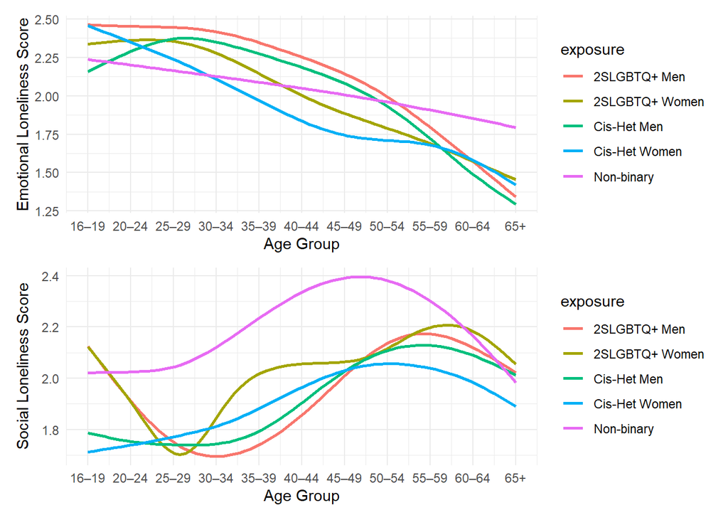

```r
p_load(ggplot2)

emo_l <- ggplot(df, aes(x = as.numeric(DEMO_age_group), y = LONELY_dejong_emotional_loneliness_sub_scale_score, color = exposure, fill = exposure)) +
  geom_smooth(se = F) +
  ylab("Emotional Loneliness Score") +
  xlab("Age Group") +
  scale_x_continuous(breaks = 1:11, labels = levels(df$DEMO_age_group)) +
  theme_minimal()

social_l <- ggplot(df, aes(x = as.numeric(DEMO_age_group), y = LONELY_dejong_social_loneliness_sub_scale_score, color = exposure, fill = exposure)) +
  geom_smooth(se = F) +
  ylab("Social Loneliness Score") +
  xlab("Age Group") +
  scale_x_continuous(breaks = 1:11, labels = levels(df$DEMO_age_group)) +
  theme_minimal()

p_load(patchwork)
p3 <- emo_l +social_l+ plot_layout(nrow = 2)
suppressWarnings(suppressMessages(print(p3)))
```

# Dealing with Missing Data

```r
# Imputation
if(file.exists(file = here("cscs","public_data","cscs_cross_2025_imputed.RDS"))){
  df_imputed <- readRDS(here("cscs","public_data","cscs_cross_2025_imputed.RDS"))} else {
    df_temp <- df %>% select(-DEMO_age_group,-DEMO_age_group_2, -exposure, -LGBTQ)

    p_load(missForest)
    df_imputed <- missForest(df_temp)$ximp
    df_imputed[c("DEMO_age_group", "DEMO_age_group_2", "exposure", "LGBTQ")] <- df[c("DEMO_age_group", "DEMO_age_group_2", "exposure", "LGBTQ")]
    saveRDS(df_imputed, file = here("cscs","public_data","cscs_cross_2025_imputed.RDS"))}

# Listwise deletion
df_complete_cases <- df %>% filter(complete.cases(.))
```

# Reducing data dimensionality

Clustering activities

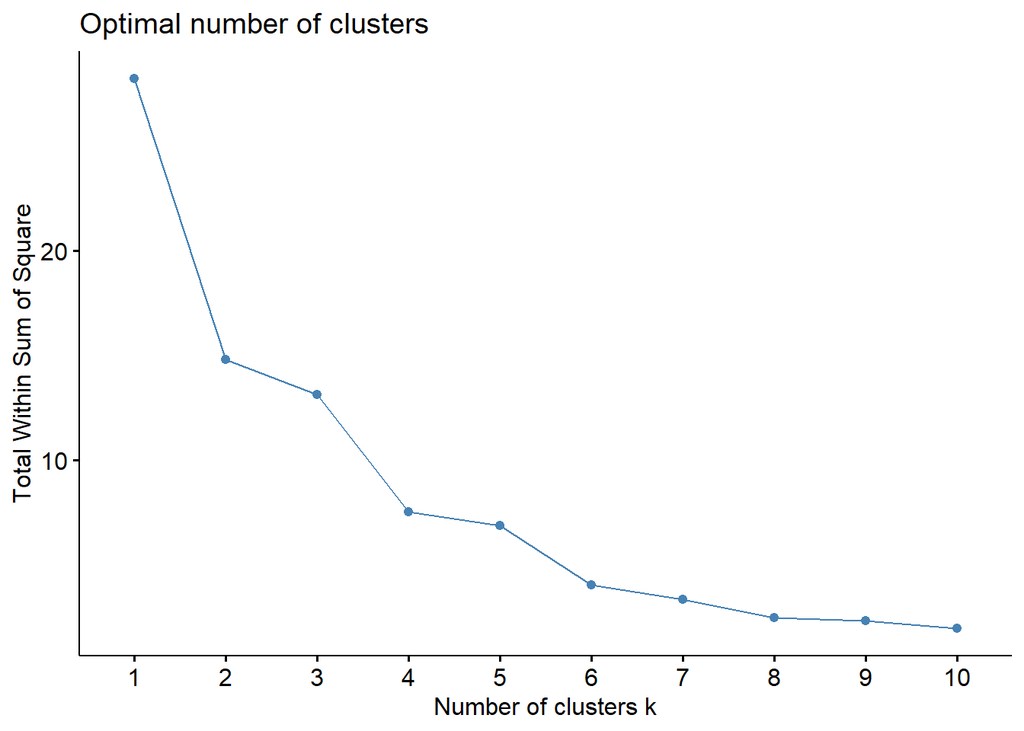

```r
p_load(FactoMineR)
activities_mca <- MCA(df_imputed[activities_vars], graph = F)
coords <- activities_mca$var$coord

p_load(factoextra)
fviz_nbclust(activities_mca$var$coord, kmeans, method = "wss")
```

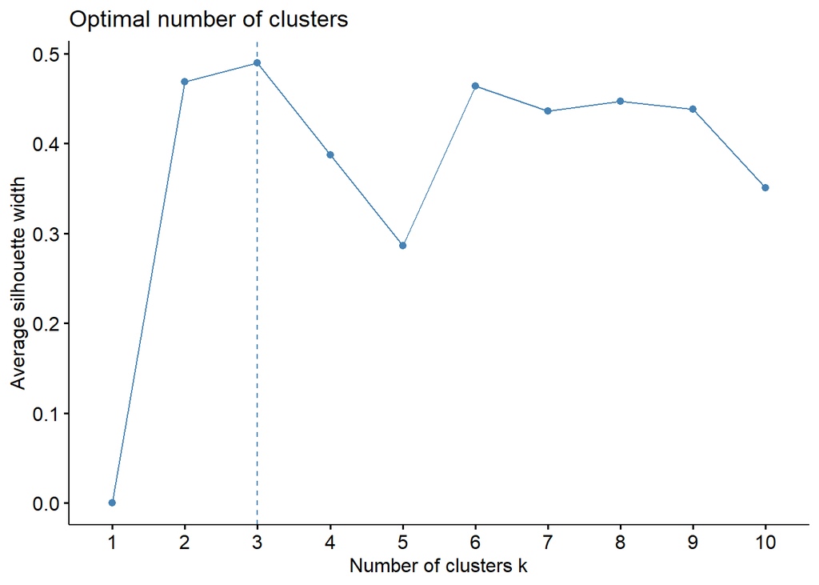

```r
fviz_nbclust(activities_mca$var$coord, kmeans, method = "silhouette") #optimal kmeans is 3
```

```r
kmeans_result <- kmeans(coords, centers = 3)

cluster1 <- names(kmeans_result$cluster[kmeans_result$cluster==1])
cluster2 <- names(kmeans_result$cluster[kmeans_result$cluster==2])
#names(kmeans_result$cluster[kmeans_result$cluster==3]) # ALL marked as no

cluster1 <- sub("_Yes","",cluster1)
cluster2 <- sub("_Yes","",cluster2)
```

Clustering social patterns

```r
df_simplified <- df_imputed %>%
  mutate(
    intimate_activities = rowSums(across(all_of(cluster1), ~ .x == "Yes")),
    other_activities = rowSums(across(all_of(cluster2), ~ .x == "Yes"))) %>% select(-all_of(activities_vars), -LGBTQ, -exposure, -DEMO_age,-DEMO_age_group)
df_simplified[11:23] <- lapply(df_simplified[11:23], as.numeric)
pca_social_patterns <- prcomp(df_simplified[11:23],center = TRUE,scale. = T)
summary(pca_social_patterns)
```

```
## Importance of components:
##                           PC1    PC2    PC3    PC4     PC5     PC6     PC7
## Standard deviation     2.1335 1.3738 1.3353 1.1928 0.87112 0.76686 0.67910
## Proportion of Variance 0.3501 0.1452 0.1371 0.1094 0.05837 0.04524 0.03548
## Cumulative Proportion  0.3501 0.4953 0.6325 0.7419 0.80028 0.84552 0.88099
##                            PC8     PC9    PC10    PC11    PC12    PC13
## Standard deviation     0.58883 0.55710 0.52075 0.49881 0.45484 0.40389
## Proportion of Variance 0.02667 0.02387 0.02086 0.01914 0.01591 0.01255
## Cumulative Proportion  0.90766 0.93154 0.95240 0.97154 0.98745 1.00000
```

```r
#Eigenvalues
pca_social_patterns$sdev^2
```

```
##  [1] 4.5518085 1.8872667 1.7829874 1.4227666 0.7588503 0.5880669 0.4611791
##  [8] 0.3467179 0.3103639 0.2711815 0.2488092 0.2068768 0.1631251
```

```r
#First 4 components explain up to 74% of the variance.
pca_scores <- as.data.frame(pca_social_patterns$x[, 1:4])
loadings <- pca_social_patterns$rotation[, 1:4]
View(loadings)
factors_social_pattern <- c("family_friends","neighbours_coworkers", "friends_neighbours", "neighbours_family")
df_simplified[factors_social_pattern] <- pca_scores
df_simplified <- df_simplified %>% select(-c(11:23))
```

Separating outcomes for loneliness dimensions

```r
colnames(df_simplified) <- sub("DEMO_","",colnames(df_simplified))
colnames(df_simplified) <- sub("GEO_","",colnames(df_simplified))
colnames(df_simplified) <- sub("LONELY_","",colnames(df_simplified))
colnames(df_simplified) <- sub("CONNECTION_social_","",colnames(df_simplified))
colnames(df_simplified) <- sub("WELLNESS_","",colnames(df_simplified))

df_simplified$social_loneliness <- factor(df_simplified$dejong_social_loneliness_sub_scale_score,
                    levels = c(0, 1, 2, 3),
                    labels = c("class0", "class1", "class2", "class3"))

df_simplified$emotional_loneliness <- factor(df_simplified$dejong_emotional_loneliness_sub_scale_score,
                    levels = c(0, 1, 2, 3),
                    labels = c("class0", "class1", "class2", "class3"))

df_simplified$dejong_emotional_social_loneliness_scale_score <- NULL
df_simplified$dejong_emotional_loneliness_sub_scale_score <- NULL
df_simplified$dejong_social_loneliness_sub_scale_score <- NULL
```

# Variable selection through random forest

```r
p_load(Boruta)
social_loneliness_vars <- Boruta(social_loneliness ~ .,
                        data = df_simplified %>% select(-emotional_loneliness),
                        doTrace = 0,
                        maxRuns = 50)

emotional_loneliness_vars <- Boruta(emotional_loneliness ~ .,
                        data = df_simplified %>% select(-social_loneliness),
                        doTrace = 0,
                        maxRuns = 50)
```

# DAG creation

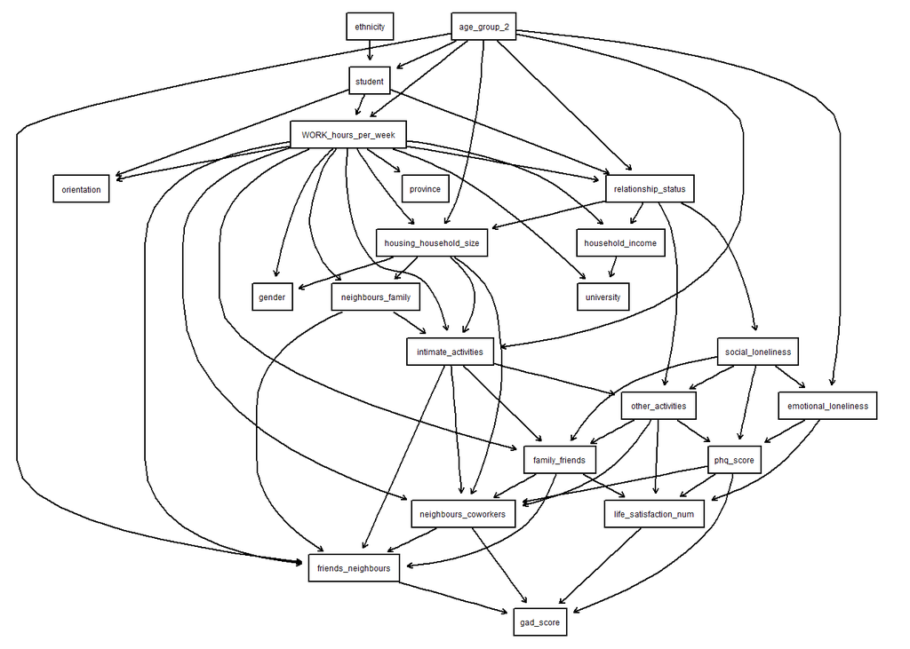

```r
p_load(bnlearn)

df_simplified <- df_simplified %>% select(-DATASET)
born_with <- c("age_group_2", "gender", "orientation", "ethnicity")
other_vars <- colnames(df_simplified)[!colnames(df_simplified) %in% born_with]

blacklist <- expand.grid(
  from = other_vars,
  to = c("age_group_2", "ethnicity")
)

blacklist <- rbind(blacklist, expand.grid(
  from = born_with,
  to = born_with
))
# Learn DAG with Hill-Climbing (score-based)
dag_hc <- hc(df_simplified,blacklist = blacklist)




# Plot the result
p_load(BiocManager)
p_load(Rgraphviz)
graphviz.plot(dag_hc)
```

```r
strength <- arc.strength(dag_hc, data = df_simplified)
strength %>% View()
```

#Optional RANDOM FOREST direct analysis

```r
p_load(randomForest)
p_load(caret)

set.seed(123)


# Set up tuning grid
tune_grid <- expand.grid(mtry = c(2, 4, 6, 8, 10))

# Train model using 5-fold cross-validation
ctrl <- trainControl(method = "cv", number = 5, classProbs = TRUE, summaryFunction = multiClassSummary)

rf_social_loneliness_model <- train(
  social_loneliness ~ .,
  data = df_simplified %>% select(-emotional_loneliness),
  method = "rf",
  trControl = ctrl,
  tuneGrid = tune_grid,
  metric = "Kappa",
  ntree = 500
)

rf_emotional_loneliness_model <- train(
  emotional_loneliness ~ .,
  data = df_simplified %>% select(-social_loneliness),
  method = "rf",
  trControl = ctrl,
  tuneGrid = tune_grid,
  metric = "Kappa",
  ntree = 500
)

# Review results
social_imp_vars <- varImp(rf_social_loneliness_model)$importance
social_imp_vars$prop <- social_imp_vars$Overall/sum(social_imp_vars$Overall)

social_imp_vars$Include <- ifelse(social_imp_vars$Overall >=(max(social_imp_vars$Overall)*.1),T,F)

emo_imp_vars <- varImp(rf_emotional_loneliness_model)$importance
emo_imp_vars$Include <- ifelse(emo_imp_vars$Overall >=(max(emo_imp_vars$Overall)*.1),T,F)
```